# Absentee Voting Trends in the 2023 Municipal Elections

In the most recent municipal elections in Georgia, a pattern emerges as we delve into the intricacies of early and absentee voting trends across the state's diverse counties.

Here is a map that elucidates these voting tendencies, showcase voter participation.

There are discernible variances in voting activity across different regions. The color gradients represent the ranges of voter turnout, offering a visual narrative that brings the data to life. From the bustling urban centers to the tranquil rural areas, the map captures the essence of Georgia’s electoral landscape.

Urban vs. Rural Divide, The urban counties, with their denser populations, exhibit higher voter turnouts in early and absentee voting. This trend underscores the pivotal role of urban areas in shaping the electoral outcome. Certain regions display unique voting behaviors, reflecting the socio-political fabric of the communities. These nuances are crucial in understanding the broader electoral dynamics. Accessibility and Engagement: The map raises important questions about voter accessibility and engagement, particularly in regions with lower turnout. It underscores the need for initiatives to bolster voter participation and ensure that every voice is heard.

Moving forward, the path forward calls for a concerted effort to address disparities in voter participation. Whether through educational initiatives, infrastructural improvements, or policy reforms, the goal remains clear: to cultivate an electoral landscape that is as diverse and vibrant as the population it serves.

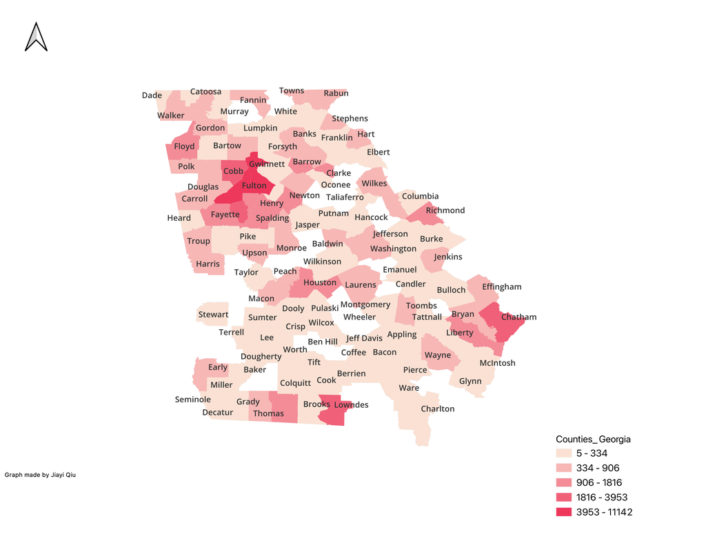

```python
from IPython.display import Image
Image(filename='VotingTurnout33.png')
```